# Práctica 5 - Un poquito de visualización

AE

22/10/2020

# Previo

## Paquetería

```r
if (!require("pacman")) install.packages("pacman") # instala pacman si se requiere
```

```r
pacman::p_load(tidyverse,
               readxl,writexl,googlesheets4, # importar hojas de cálculo
               haven, foreign, # importación de dta y sav
               sjlabelled, # etiquetas
               janitor, skimr, #limpieza y verificación
               imputeTS, # para imputar valores
               srvyr, # Para el diseño muestral
               esquisse) # para usar ggplot de manera más amigable
```

## Directorio

En caso que no tengas un proyecto,establecer el diretorio puede ayudar

*¡Recuerda establecer tu directorio!*

```r
setwd("/Users/anaescoto/Dropbox/2020/2021-1 R para Demográfos/repo/R_Demo")
```

## Bases

Base de ECOVID - ML

```r
ecovid0420 <- read_dta("https://github.com/aniuxa/R_Demo/raw/master/datos/ecovid0420.dta")
```

También vamos usar la base de Índice de Competitividad Estatal, desarrollado por el Instituto Mexicano de Competitividad. (véase http://imco.org.mx/indices/que-no-vuelva-a-pasar-estados-prevenidos-valen-por-dos/)

```r
url <- "https://github.com/aniuxa/R_Demo/raw/master/datos/ICE_2018.xlsx"
destfile <- "ICE_2018.xlsx"
curl::curl_download(url, destfile)
ICE_2018 <- read_excel(destfile, sheet="para_importar")
```

```
## * `` -> ...102
## * `` -> ...105
```

Una vez “bajado”, a limpiar

```r
ICE_2018 <- clean_names(ICE_2018) # limpia los nombres
```

# ¿Cuál es el mejor gráfico?

Hay cursos específicos de visualización de datos. Es maravilloso pero también requiere que estudiemos bien qué tipo de datos tenemos y cuáles son nuestros objetivos.

Me gusta mucho este recurso: https://www.data-to-viz.com/

# Gráficos de base

“plot()” Es la función más simple. Y es otro comando “listo”

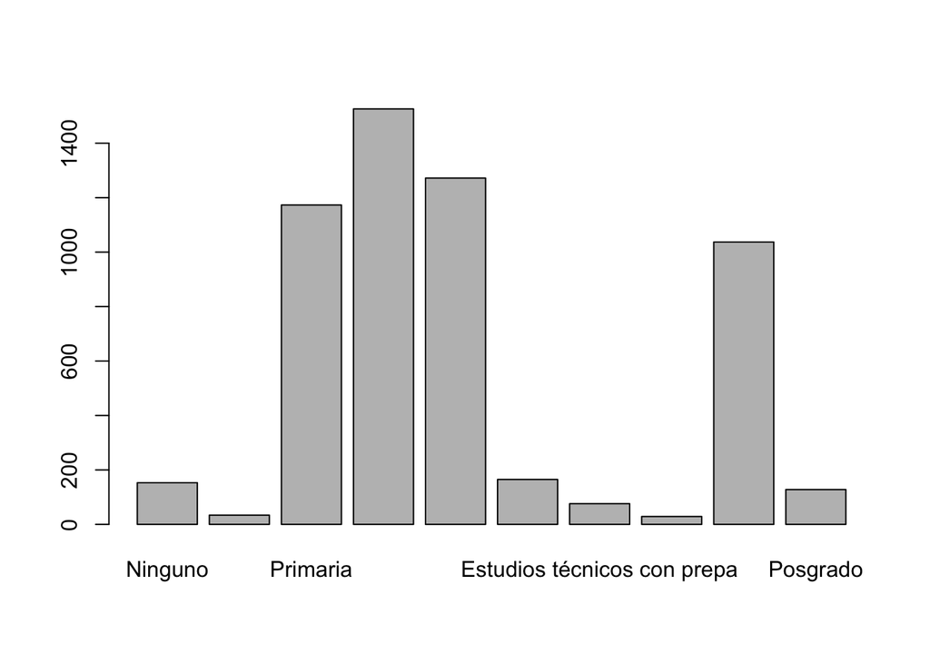

```r
  plot(as_label(ecovid0420$pb3))
```

Esto es igual que:

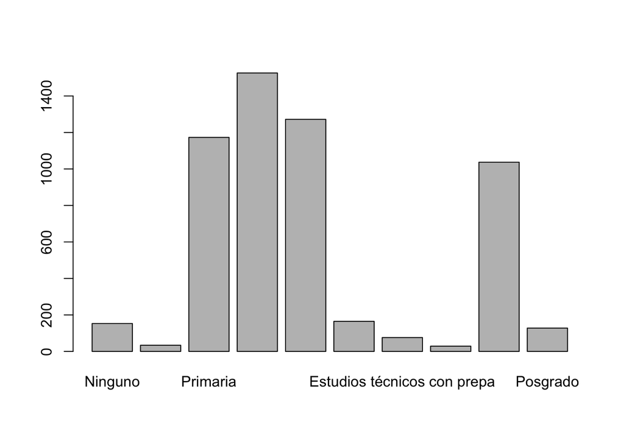

```r
barplot(table(as_label(ecovid0420$pb3)))
```

Histograma y el boxplot

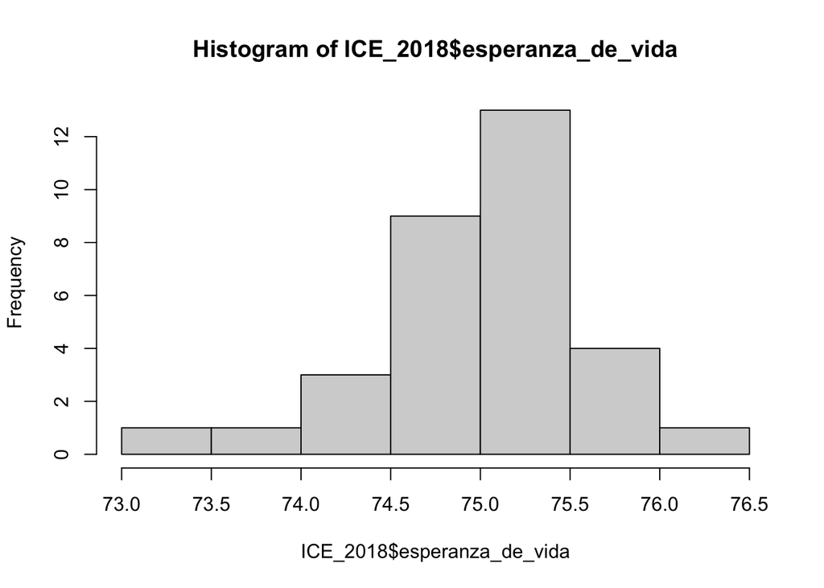

```r
hist(ICE_2018$esperanza_de_vida)
```

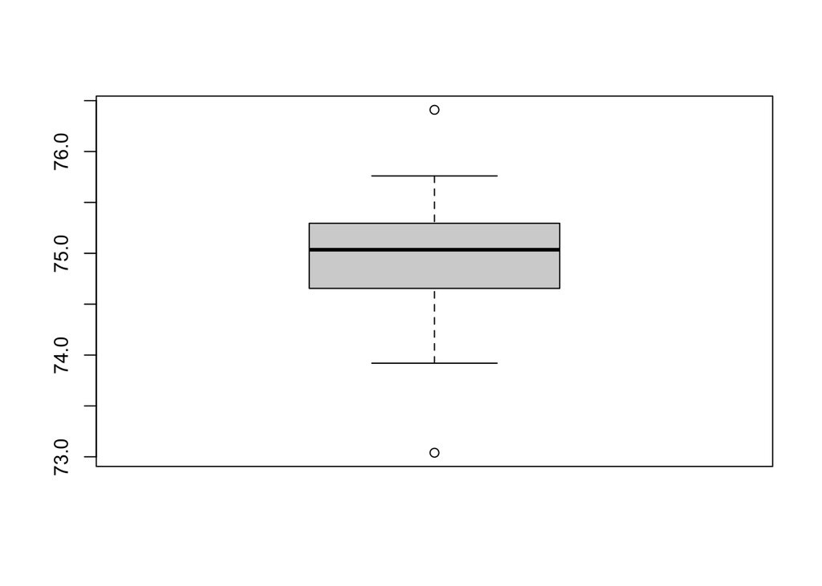

```r
boxplot(ICE_2018$esperanza_de_vida)
```

# Gráficos con ggplot

Hoy vamos a presentar a un gran paquete ¡Es de los famosos! Y tiene más de diez años.

- https://qz.com/1007328/all-hail-ggplot2-the-code-powering-all-those-excellent-charts-is-10-years-old/

“gg” proviene de “Grammar of Graphics”, funciona un poco como sintácticamente, de ahí su nombre.

Algunos recursos para aprender ggplot

- https://ggplot2-book.org/ hecha por el mero mero.
- http://sape.inf.usi.ch/quick-reference/ggplot2
- https://raw.githubusercontent.com/rstudio/cheatsheets/master/data-visualization-2.1.pdf

Vamos a revisar una presentación que es muy interesante

- https://evamaerey.github.io/ggplot2_grammar_guide/ggplot2_grammar_guide.html
- https://huygens.science.uva.nl/ggPlotteR/ Hace gráficos de ggplot con la base de datos de Gapminder

# Un lienzo para dibujar

Para hacer un gráfico, ggplot2 tiene el comando “ggplot()”. Hacer gráficos con esta función tiene una lógica aditiva. Lo ideal es que iniciemos estableciendo el mapeo estético de nuestro gráfico, con el comando aes()

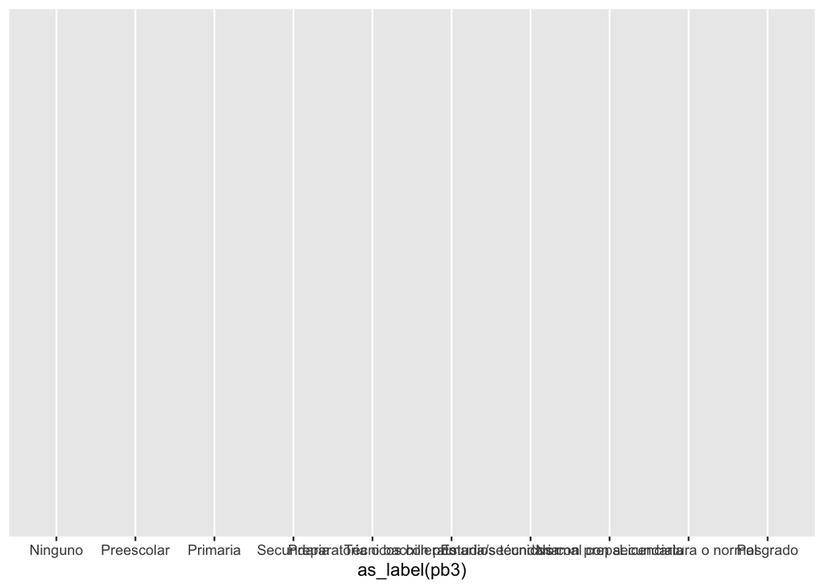

```r
g1<-ecovid0420 %>%
  ggplot(aes(as_label(pb3)))

g1 # imprime el lienzo
```

# Gráficos univariados

## Para cualitativas

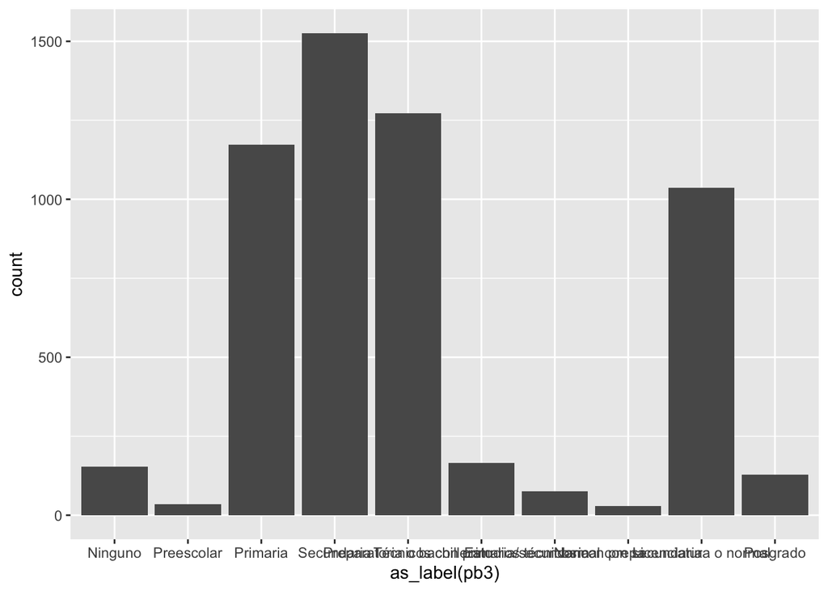

```r
g1 + geom_bar()
```

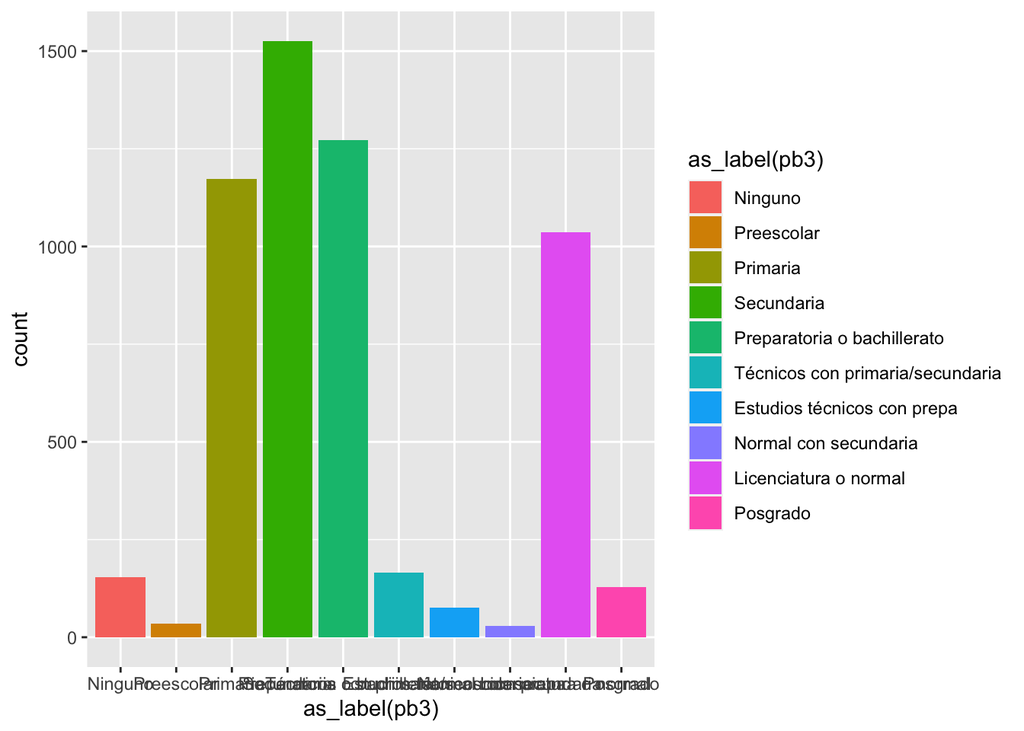

```r
g1 +  geom_bar(aes(
  fill = as_label(pb3)
  )) # colorea la geometría
```

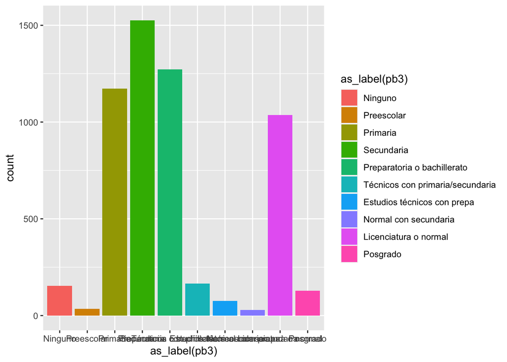

```r
# Esto es equivalente

ecovid0420 %>%
  ggplot(aes(as_label(pb3),
             fill = as_label(pb3)
             )
         ) + geom_bar()
```

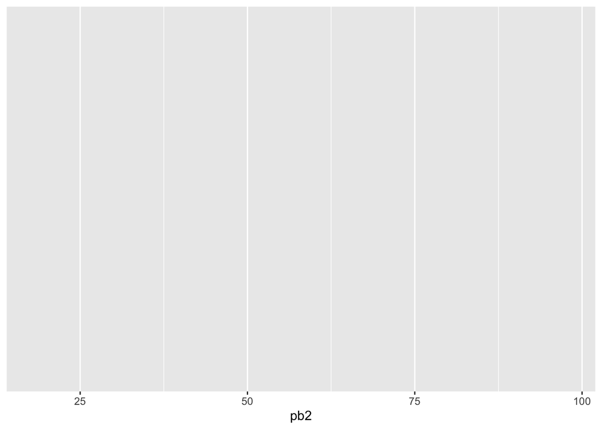

```r
g2<-ecovid0420 %>%
  ggplot(aes(pb2))

g2 # imprime el lienzo
```

### Histograma

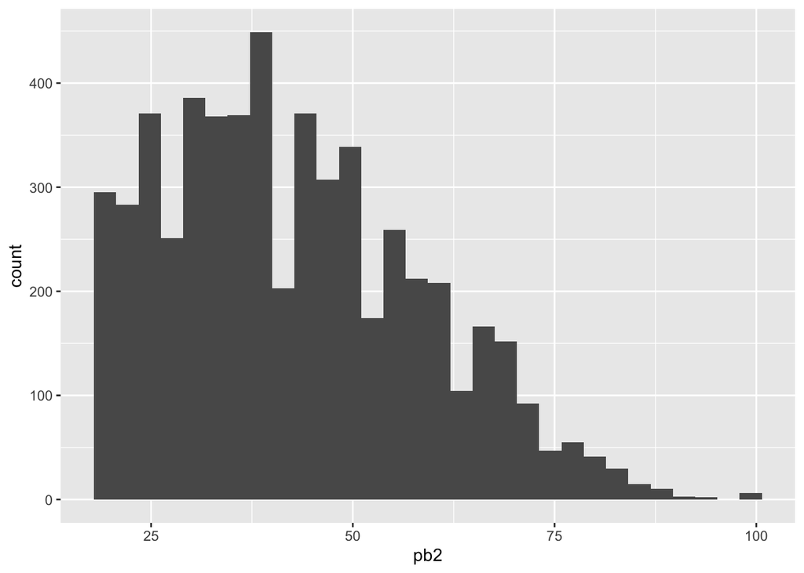

```r
g2 + geom_histogram()
```

### Densidad

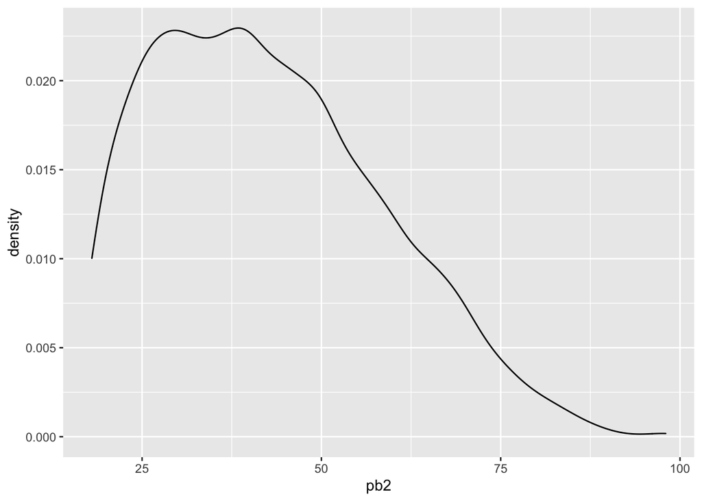

```r
g2 + geom_density()
```

# Gráficos bivariados

## Cuali-cuali

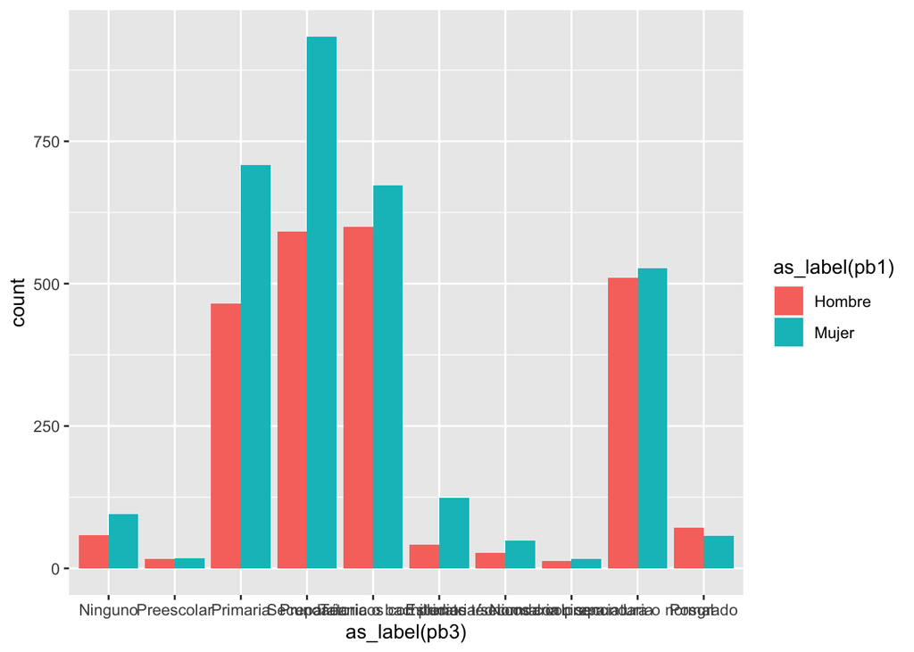

```r
g1 +  geom_bar(aes(fill = as_label(pb1)),
              position="dodge") #pone las categorías lado a lado y no apiladas
```

Otra manera interesante de observar estas variables, es que estándo apiladas, cada categoría de escolaridad se entendiera como una unidad:

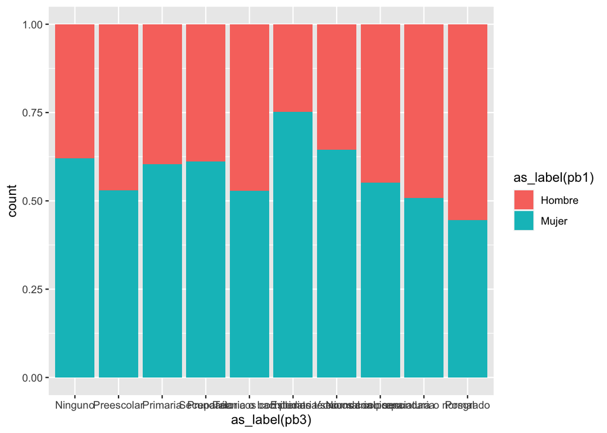

```r
g_bivariado <- g1 +  geom_bar(aes(fill = as_label(pb1)),
              position="fill") # cada categoría "llena" a una unidad

g_bivariado
```

Escalas de color: RcolorBrewer es el más famoso.

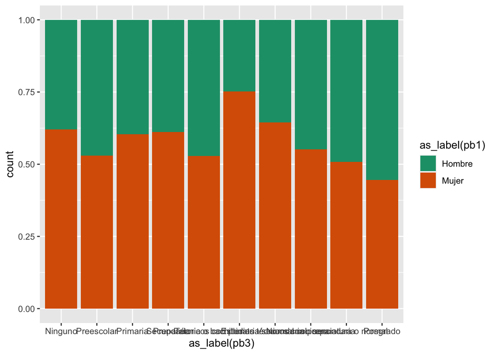

```r
g_bivariado + scale_fill_brewer(palette = "Dark2")
```

Cambiamos el tema:

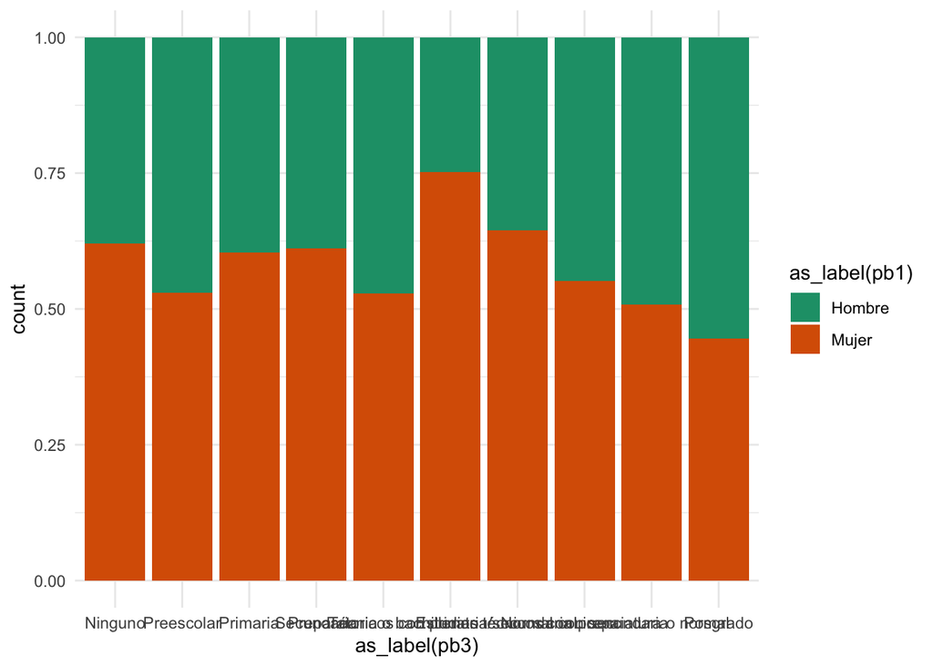

```r
g_bivariado + scale_fill_brewer(palette = "Dark2") + theme_minimal()
```

# Un atajo “esquisse”

Si la lógica de las capas y lienzos parece un poco complicada para graficar con ggplot, el paquete “esquisse” tiene un complemento. Cuando lo instalamos con pacman más arriba, se puede observar el complemento:

```r
#library(esquisse)
```

Hoy desde el complemento podemos acceder a el siguiente menú y seleccionar nuestra base.

[figure not shown]

En tu barra de íconos de Rstudio

Una vez seleccionada, puedes hacer “drag and drop” de las variables y elegir el tipo de gráfico, incluso puedes hacer filtro con las variables disponibles

Puedes exportar esto a una imagen, a powerpoint o como código a ejecutar en RStudio. Esta herramienta es muy útil para irnos acostumbrando al código de ggplot que puede ser bastante complicado en los primeros acercamientos

# Gráficos bivariados

Para los gráficos “cuanti-cuanti”, iniciamos con un gráfico de dispersión o *scatter*

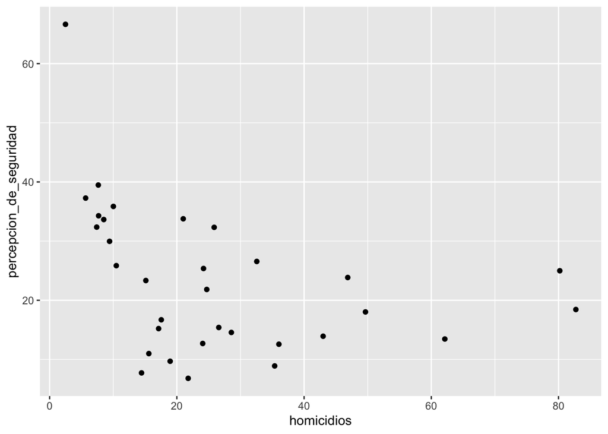

```r
ICE_2018 %>%
  ggplot(aes(homicidios,percepcion_de_seguridad)) +
  geom_point() #puntito
```

Modificaciones

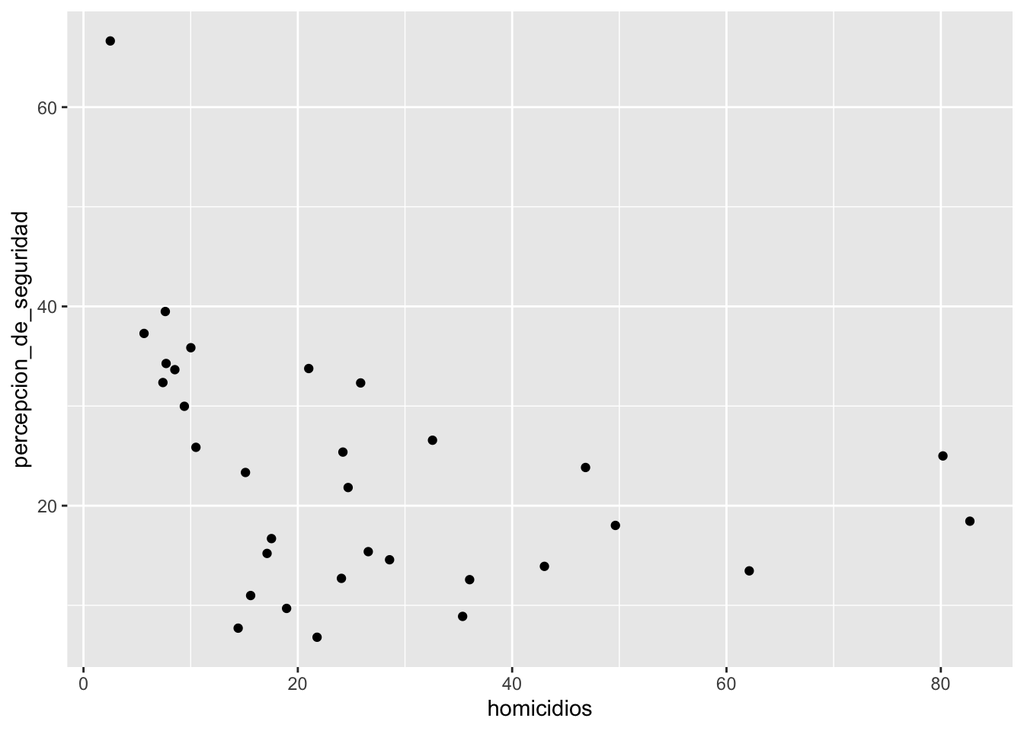

```r
 # geometría "jitter"
ICE_2018 %>%
  ggplot(aes(homicidios,percepcion_de_seguridad)) +
  geom_jitter() # puntito pero "separado"
```

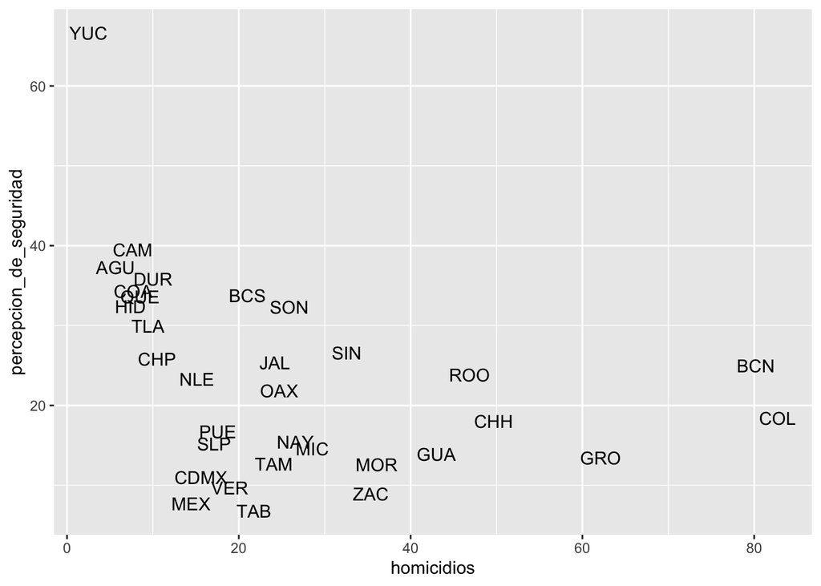

```r
# geometría "text"

ICE_2018 %>%
  ggplot(aes(homicidios,percepcion_de_seguridad)) +
  geom_text(aes(label=edo2)) # un texto en lugar de punto
```

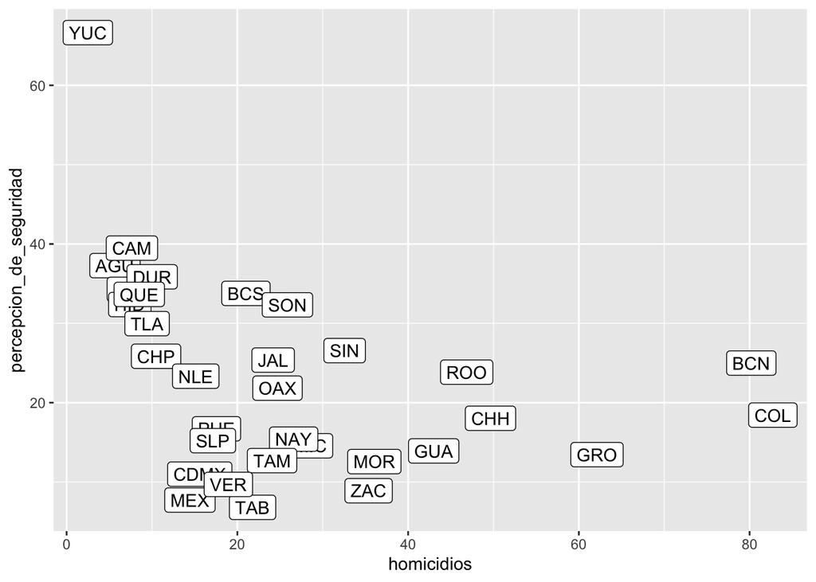

```r
# geometría "label"

ICE_2018 %>%
  ggplot(aes(homicidios,percepcion_de_seguridad)) +
  geom_label(aes(label=edo2)) # etiqueta
```

## Ya no es tan bivariado

Con *color*

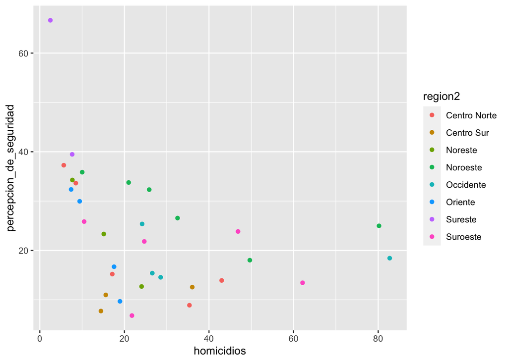

```r
ICE_2018 %>%
  ggplot(aes(x=homicidios,
             y=percepcion_de_seguridad,
             color=region2)
         ) +
  geom_point()
```

Con *shape*

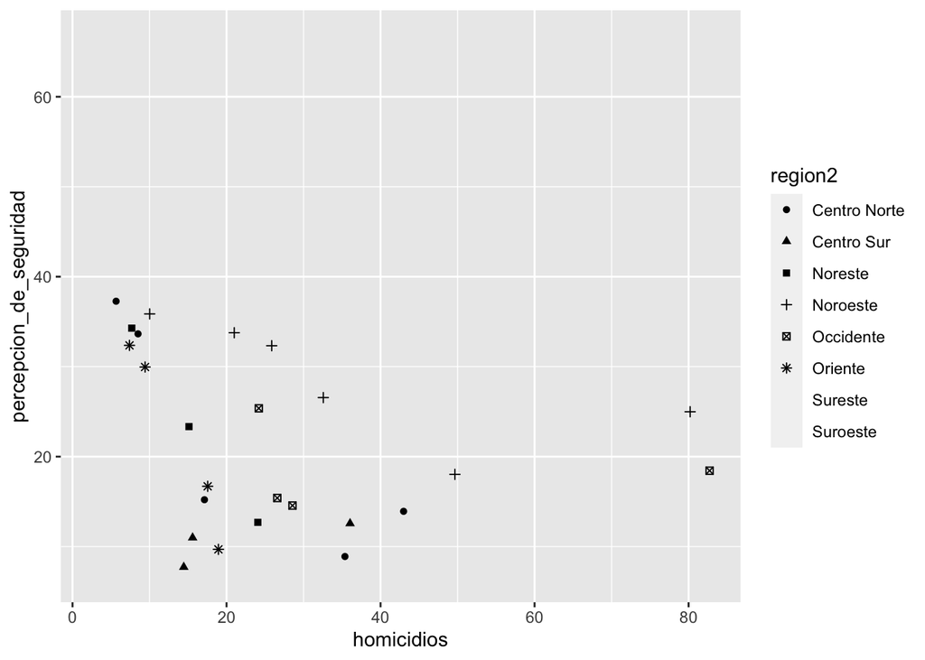

```r
ICE_2018 %>%
  ggplot(aes(x=homicidios,
             y=percepcion_de_seguridad,
             shape=region2)
  ) +
  geom_point() # ojo, nos da un "warning"
```

## *facets*

Con *facet_wrap*

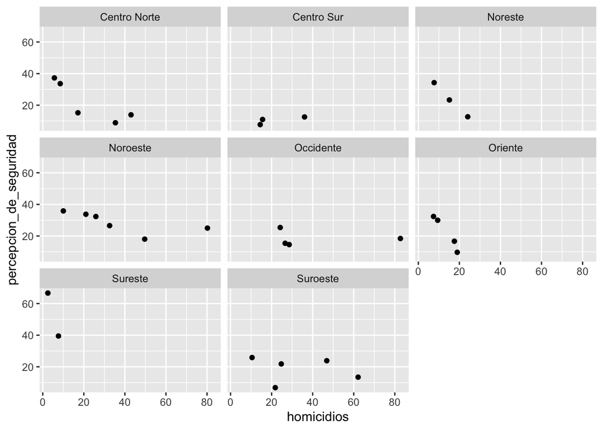

```r
ICE_2018 %>%
  ggplot(aes(x=homicidios,
             y=percepcion_de_seguridad)) +
  geom_point() + facet_wrap(~region2)
```

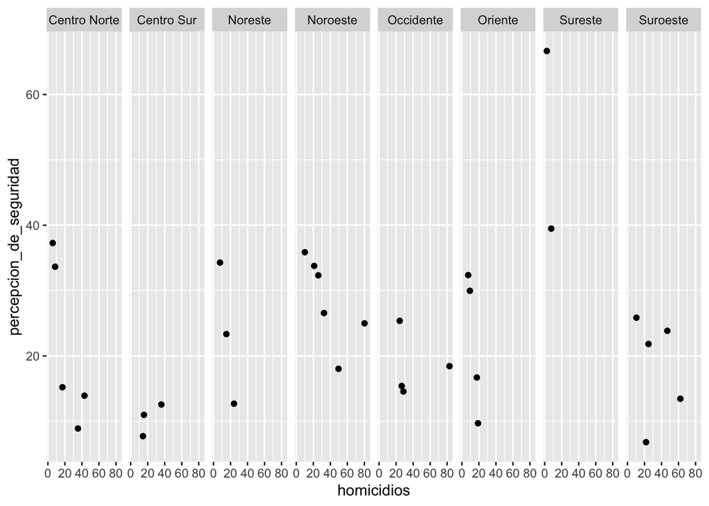

```r
ICE_2018 %>%
  ggplot(aes(x=homicidios,
             y=percepcion_de_seguridad)) +
  geom_point() + facet_grid(.~region2)
```

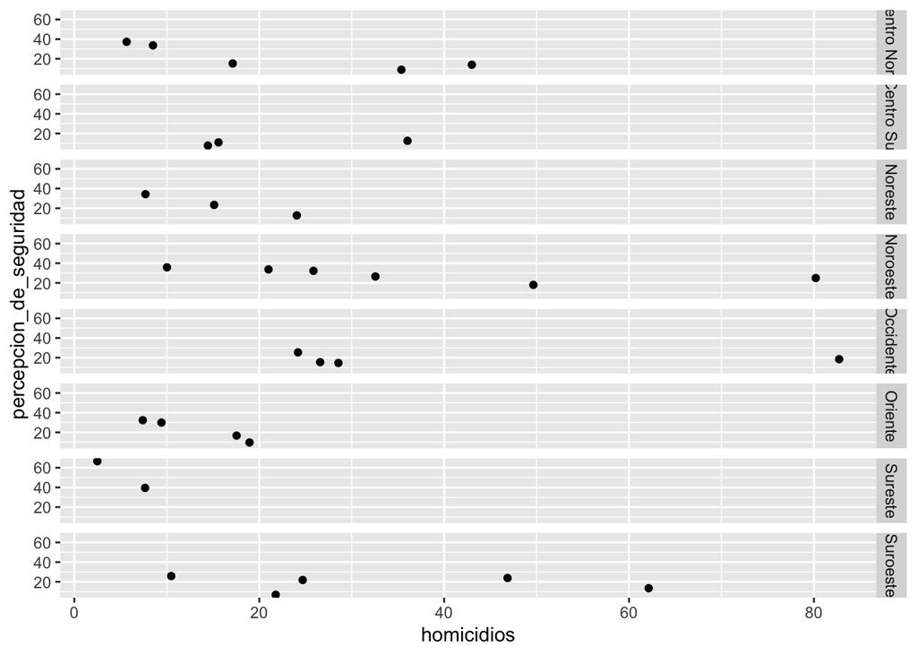

```r
ICE_2018 %>%
  ggplot(aes(x=homicidios,
             y=percepcion_de_seguridad)) +
  geom_point() +
  facet_grid(region2~.)
```

## Ajustes *smooth*

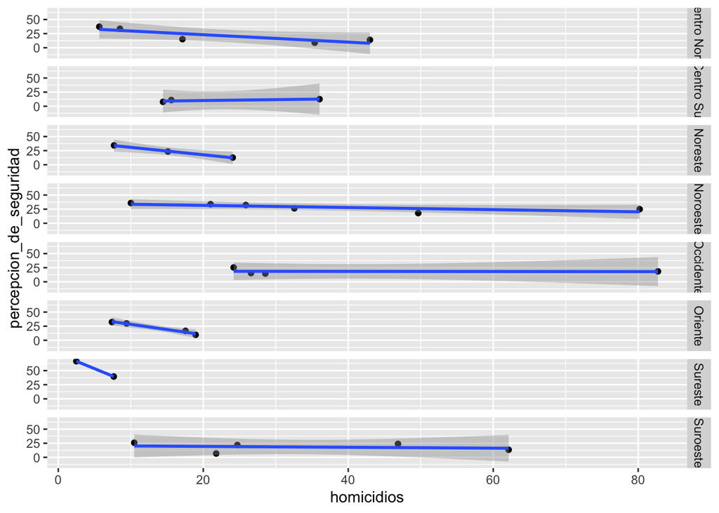

```r
ICE_2018 %>%
  ggplot(aes(x=homicidios,
             y=percepcion_de_seguridad)) +
  geom_point() +
  geom_smooth(method="lm") +
  facet_grid(region2~.)
```

Enchulando tantito:

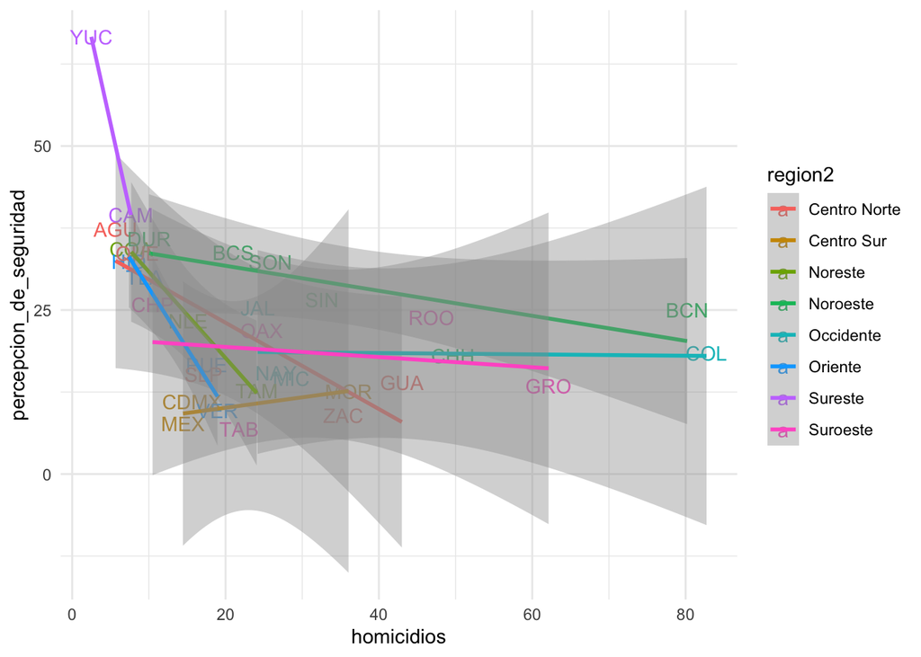

```r
ICE_2018 %>%
  ggplot(aes(x=homicidios,
             y=percepcion_de_seguridad,
             color=region2)) +
  geom_text(aes(label=edo2)) +
  geom_smooth(method="lm") + scale_fill_brewer(palette = "Dark2") +
  theme_minimal()
```

## Una cuarta variable

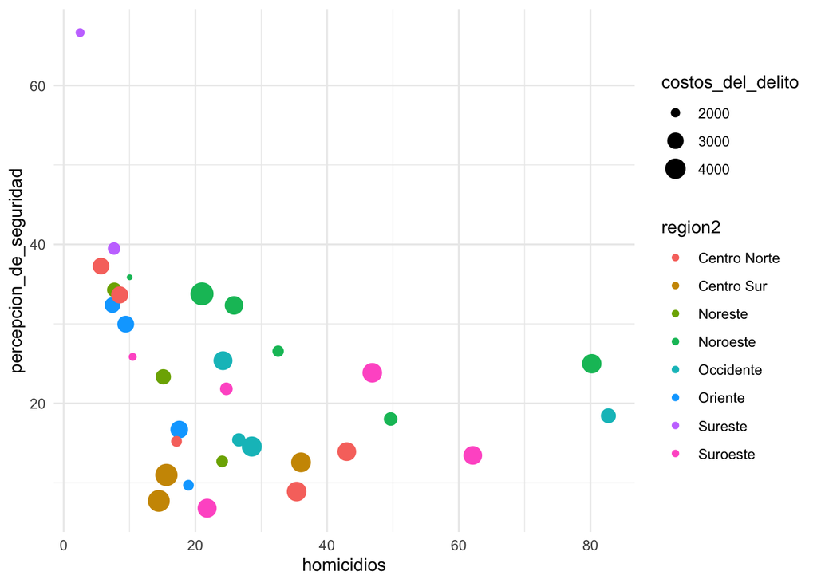

```r
ICE_2018 %>%
  ggplot(aes(x=homicidios,
             y=percepcion_de_seguridad,
             color=region2)) +
  geom_point(aes(size=costos_del_delito))+ # ojo
  theme_minimal()
```

No es lo mismo, pero es igual:

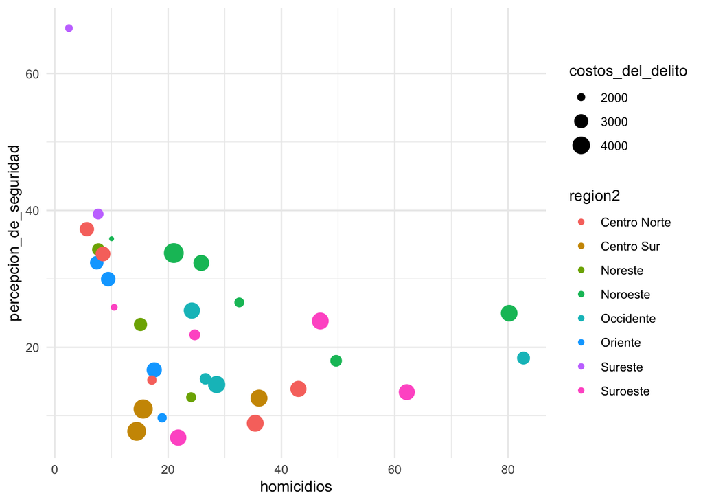

```r
ICE_2018 %>%
  ggplot(aes(x=homicidios,
             y=percepcion_de_seguridad,
             color=region2,
             size=costos_del_delito)) +
  geom_point()+
  theme_minimal()
```

Algunas opciones interesantes:

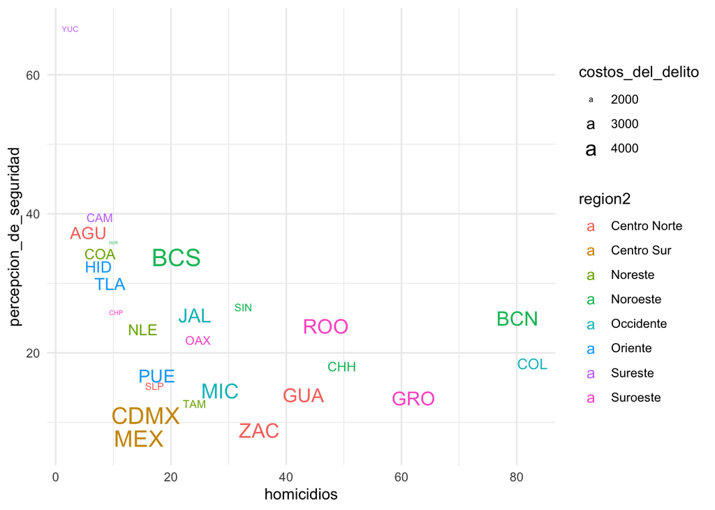

```r
ICE_2018 %>%
  ggplot(aes(x=homicidios,
             y=percepcion_de_seguridad,
             color=region2,
             size=costos_del_delito)) +
  geom_text(aes(label=edo2),
            check_overlap = TRUE)+
  theme_minimal()
```

# Tarea

1. Realiza dos gráficos. Uno de una sola variable y otro con dos variables, el que sea de tu agrado, con las variables que te sientes cómoda o cómodo, en la base de datos de tu elección
- Puedes modificarlo usando el paquete “esquisse”. Envía las imágenes en el primer reactivo
2. Envía el script, en el segundo reactivo

https://forms.gle/sqqhPxjxQLLLJRgAA